# 8 Split-apply-combine

In **Part II** of the book, we introduced **transform pipelines** to process the `values` and the `domain` of geotables using high-level abstractions that preserve geospatial information. In this chapter, we start to introduce other tools to **query** geotables after they have been pre-processed by pipelines.

## 8.1 Motivation

In geospatial data science, geoscientific questions are often posed in terms of both the `values` and the `domain` of a geotable. For example:

1. **Where** are the areas with high probability of landslide?
2. What is the average rainfall **per watershed** over the last year?
3. How much lithium will be mined from each **geological unit**?
4. What is the variation of log-permeability per **depositional facies**?

The word “where” is often present in these questions to indicate that answers must be georeferenced. If the variable of interest is already present in the geotable, then we can effectively answer “where” questions using the `viewer` and the `Filter` transform from previous chapters:

```julia
geotable |> Filter(row -> row.probability > 0.9) |> viewer
```

If the variable of interest is not present in the geotable, or if the “where” word is not present in the original question, then there will be some reference to “geospatial units” on which geostatistics must be computed. These questions can be answered with a **geospatial** version of the **split-apply-combine** strategy (Wickham 2011) from data science. Our framework provides the `@groupby`, `@transform` and `@combine` macros to split-apply-combine geotables.

## 8.2 Bonnie data set

We will use the `Bonnie` data set to illustrate our geospatial split-apply-combine:

> The Bonnie Project Example is under copyright of Transmin Metallurgical Consultants, 2019. It is issued under the Creative Commons Attribution-ShareAlike 4.0 International Public License.

```julia
using GeoIO

gtb = GeoIO.load("data/bonnie.csv", coords = ("EAST", "NORTH", "RL"))
```

19608 rows omitted

| 19618×9 GeoTable over 19618 PointSet Auppm Continuous [NoUnits] | 19618×9 GeoTable over 19618 PointSet Agppm Continuous [NoUnits] | 19618×9 GeoTable over 19618 PointSet Cuppm Continuous [NoUnits] | 19618×9 GeoTable over 19618 PointSet Asppm Continuous [NoUnits] | 19618×9 GeoTable over 19618 PointSet Sper Continuous [NoUnits] | 19618×9 GeoTable over 19618 PointSet CODE Categorical [NoUnits] | 19618×9 GeoTable over 19618 PointSet OX Categorical [NoUnits] | 19618×9 GeoTable over 19618 PointSet ISBD Continuous [NoUnits] | 19618×9 GeoTable over 19618 PointSet geometry Point 🖈 Cartesian{NoDatum} |
| --- | --- | --- | --- | --- | --- | --- | --- | --- |
| 0.407 | 2.335 | 1311.0 | 27.0 | 0.01 | C1 | TR1 | 2.42 | (x: 243940.0 m, y: 1.00223e6 m, z: 1855.0 m) |
| 0.407 | 2.335 | 1311.0 | 27.0 | 0.01 | C1 | TR1 | 1.98 | (x: 243945.0 m, y: 1.00223e6 m, z: 1855.0 m) |
| 0.407 | 2.335 | 1311.0 | 27.0 | 0.01 | C1 | TR1 | 2.068 | (x: 243950.0 m, y: 1.00226e6 m, z: 1855.0 m) |
| 0.385 | 2.1 | 572.0 | 0.0 | 0.0 | C1 | TR1 | 2.222 | (x: 243965.0 m, y: 1.00226e6 m, z: 1855.0 m) |
| 0.385 | 2.1 | 572.0 | 0.0 | 0.0 | C1 | TR1 | 2.156 | (x: 243970.0 m, y: 1.00226e6 m, z: 1855.0 m) |
| 0.385 | 2.1 | 572.0 | 0.0 | 0.0 | C1 | OX1 | 2.08 | (x: 243960.0 m, y: 1.00227e6 m, z: 1855.0 m) |
| 0.385 | 2.1 | 572.0 | 0.0 | 0.0 | C1 | OX1 | 2.06 | (x: 243965.0 m, y: 1.00227e6 m, z: 1855.0 m) |
| 0.385 | 2.1 | 572.0 | 0.0 | 0.0 | C1 | OX1 | 1.9 | (x: 243970.0 m, y: 1.00227e6 m, z: 1855.0 m) |
| 0.42152 | 1.422 | 852.36 | 22.85 | 2.4078 | C1 | TR1 | 2.024 | (x: 243930.0 m, y: 1.00222e6 m, z: 1860.0 m) |
| 0.41747 | 1.429 | 832.36 | 21.87 | 1.9388 | C1 | TR1 | 2.112 | (x: 243935.0 m, y: 1.00222e6 m, z: 1860.0 m) |
| ⋮ | ⋮ | ⋮ | ⋮ | ⋮ | ⋮ | ⋮ | ⋮ | ⋮ |

It represents a 3D mineral deposit with grades in parts per million (ppm), sulfur contaminant in percent, and other categorical variables with geological and lithological units:

```julia
names(gtb)
```

```
9-element Vector{String}:
 "Auppm"
 "Agppm"
 "Cuppm"
 "Asppm"
 "Sper"
 "CODE"
 "OX"
 "ISBD"
 "geometry"
```

The “EAST”, “NORTH” and “RL” coordinates used to `georef` the CSV file represent the centroids of the mining blocks. The sides of these blocks are provided as metadata (e.g., 5x5x5):

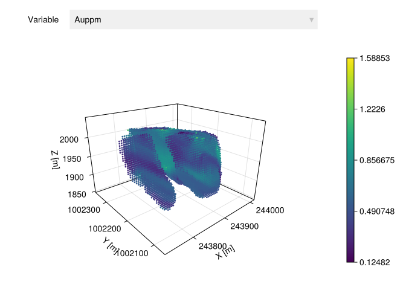

```julia
gtb |> viewer
```

Let’s clean the geotable using what we learned in previous chapters. We will reject the column with sulfur, will rename the variables for greater readability, and will drop missing values. We will also add units to some of the variables using bracket notation:

```julia
clean = Reject("Sper") →
        Rename("Agppm" => "Ag [ppm]",
               "Auppm" => "Au [ppm]",
               "Asppm" => "As [ppm]",
               "Cuppm" => "Cu [ppm]",
               "ISBD" => "ρ [Mg/m^3]",
               "CODE" => "geo",
               "OX" => "litho") →
        DropMissing() →
        Unitify()

gtb = gtb |> clean
```

19538 rows omitted

| 19548×8 GeoTable over 19548 view(::PointSet, [1, 2, 3, 4, ..., 19615, 19616, 19617, 19618]) Au Continuous [ppm] | 19548×8 GeoTable over 19548 view(::PointSet, [1, 2, 3, 4, ..., 19615, 19616, 19617, 19618]) Ag Continuous [ppm] | 19548×8 GeoTable over 19548 view(::PointSet, [1, 2, 3, 4, ..., 19615, 19616, 19617, 19618]) Cu Continuous [ppm] | 19548×8 GeoTable over 19548 view(::PointSet, [1, 2, 3, 4, ..., 19615, 19616, 19617, 19618]) As Continuous [ppm] | 19548×8 GeoTable over 19548 view(::PointSet, [1, 2, 3, 4, ..., 19615, 19616, 19617, 19618]) geo Categorical [NoUnits] | 19548×8 GeoTable over 19548 view(::PointSet, [1, 2, 3, 4, ..., 19615, 19616, 19617, 19618]) litho Categorical [NoUnits] | 19548×8 GeoTable over 19548 view(::PointSet, [1, 2, 3, 4, ..., 19615, 19616, 19617, 19618]) ρ Continuous [Mg m^-3] | 19548×8 GeoTable over 19548 view(::PointSet, [1, 2, 3, 4, ..., 19615, 19616, 19617, 19618]) geometry Point 🖈 Cartesian{NoDatum} |
| --- | --- | --- | --- | --- | --- | --- | --- |
| 0.407 ppm | 2.335 ppm | 1311.0 ppm | 27.0 ppm | C1 | TR1 | 2.42 Mg m^-3 | (x: 243940.0 m, y: 1.00223e6 m, z: 1855.0 m) |
| 0.407 ppm | 2.335 ppm | 1311.0 ppm | 27.0 ppm | C1 | TR1 | 1.98 Mg m^-3 | (x: 243945.0 m, y: 1.00223e6 m, z: 1855.0 m) |
| 0.407 ppm | 2.335 ppm | 1311.0 ppm | 27.0 ppm | C1 | TR1 | 2.068 Mg m^-3 | (x: 243950.0 m, y: 1.00226e6 m, z: 1855.0 m) |
| 0.385 ppm | 2.1 ppm | 572.0 ppm | 0.0 ppm | C1 | TR1 | 2.222 Mg m^-3 | (x: 243965.0 m, y: 1.00226e6 m, z: 1855.0 m) |
| 0.385 ppm | 2.1 ppm | 572.0 ppm | 0.0 ppm | C1 | TR1 | 2.156 Mg m^-3 | (x: 243970.0 m, y: 1.00226e6 m, z: 1855.0 m) |
| 0.385 ppm | 2.1 ppm | 572.0 ppm | 0.0 ppm | C1 | OX1 | 2.08 Mg m^-3 | (x: 243960.0 m, y: 1.00227e6 m, z: 1855.0 m) |
| 0.385 ppm | 2.1 ppm | 572.0 ppm | 0.0 ppm | C1 | OX1 | 2.06 Mg m^-3 | (x: 243965.0 m, y: 1.00227e6 m, z: 1855.0 m) |
| 0.385 ppm | 2.1 ppm | 572.0 ppm | 0.0 ppm | C1 | OX1 | 1.9 Mg m^-3 | (x: 243970.0 m, y: 1.00227e6 m, z: 1855.0 m) |
| 0.42152 ppm | 1.422 ppm | 852.36 ppm | 22.85 ppm | C1 | TR1 | 2.024 Mg m^-3 | (x: 243930.0 m, y: 1.00222e6 m, z: 1860.0 m) |
| 0.41747 ppm | 1.429 ppm | 832.36 ppm | 21.87 ppm | C1 | TR1 | 2.112 Mg m^-3 | (x: 243935.0 m, y: 1.00222e6 m, z: 1860.0 m) |
| ⋮ | ⋮ | ⋮ | ⋮ | ⋮ | ⋮ | ⋮ | ⋮ |

**Note**

The `Unitify` transform recognizes unit bracket notation in column names. It adds the units specified within brackets to the values of the columns, and removes the brackets from the column names.

That is a lot better! Let’s assume that we want to answer the following business question:

*What is the total mass of gold that will be mined from each geological unit?*

## 8.3 Splitting geotables

We can split geotables into lazy **geospatial partitions** based on values stored in a column. In this case, we want to split the mineral deposit in geological units stored in the `geo` column:

```julia
groups = @groupby(gtb, "geo")
```

```
2 Partition
├─ 17153×8 SubGeoTable over 17153 view(::PointSet, [1, 2, 3, 4, ..., 17203, 17204, 17205, 17206])
└─ 2395×8 SubGeoTable over 2395 view(::PointSet, [17207, 17208, 17209, 17210, ..., 19615, 19616, 19617, 19618])
metadata: rows, names
```

There are two geological units in this deposit, represented as `SubGeoTable`. We can access these units by indexing into the geospatial partition:

```julia
groups[1]
```

17143 rows omitted

| 17153×8 SubGeoTable over 17153 view(::PointSet, [1, 2, 3, 4, ..., 17203, 17204, 17205, 17206]) Au Continuous [ppm] | 17153×8 SubGeoTable over 17153 view(::PointSet, [1, 2, 3, 4, ..., 17203, 17204, 17205, 17206]) Ag Continuous [ppm] | 17153×8 SubGeoTable over 17153 view(::PointSet, [1, 2, 3, 4, ..., 17203, 17204, 17205, 17206]) Cu Continuous [ppm] | 17153×8 SubGeoTable over 17153 view(::PointSet, [1, 2, 3, 4, ..., 17203, 17204, 17205, 17206]) As Continuous [ppm] | 17153×8 SubGeoTable over 17153 view(::PointSet, [1, 2, 3, 4, ..., 17203, 17204, 17205, 17206]) geo Categorical [NoUnits] | 17153×8 SubGeoTable over 17153 view(::PointSet, [1, 2, 3, 4, ..., 17203, 17204, 17205, 17206]) litho Categorical [NoUnits] | 17153×8 SubGeoTable over 17153 view(::PointSet, [1, 2, 3, 4, ..., 17203, 17204, 17205, 17206]) ρ Continuous [Mg m^-3] | 17153×8 SubGeoTable over 17153 view(::PointSet, [1, 2, 3, 4, ..., 17203, 17204, 17205, 17206]) geometry Point 🖈 Cartesian{NoDatum} |
| --- | --- | --- | --- | --- | --- | --- | --- |
| 0.407 ppm | 2.335 ppm | 1311.0 ppm | 27.0 ppm | C1 | TR1 | 2.42 Mg m^-3 | (x: 243940.0 m, y: 1.00223e6 m, z: 1855.0 m) |
| 0.407 ppm | 2.335 ppm | 1311.0 ppm | 27.0 ppm | C1 | TR1 | 1.98 Mg m^-3 | (x: 243945.0 m, y: 1.00223e6 m, z: 1855.0 m) |
| 0.407 ppm | 2.335 ppm | 1311.0 ppm | 27.0 ppm | C1 | TR1 | 2.068 Mg m^-3 | (x: 243950.0 m, y: 1.00226e6 m, z: 1855.0 m) |
| 0.385 ppm | 2.1 ppm | 572.0 ppm | 0.0 ppm | C1 | TR1 | 2.222 Mg m^-3 | (x: 243965.0 m, y: 1.00226e6 m, z: 1855.0 m) |
| 0.385 ppm | 2.1 ppm | 572.0 ppm | 0.0 ppm | C1 | TR1 | 2.156 Mg m^-3 | (x: 243970.0 m, y: 1.00226e6 m, z: 1855.0 m) |
| 0.385 ppm | 2.1 ppm | 572.0 ppm | 0.0 ppm | C1 | OX1 | 2.08 Mg m^-3 | (x: 243960.0 m, y: 1.00227e6 m, z: 1855.0 m) |
| 0.385 ppm | 2.1 ppm | 572.0 ppm | 0.0 ppm | C1 | OX1 | 2.06 Mg m^-3 | (x: 243965.0 m, y: 1.00227e6 m, z: 1855.0 m) |
| 0.385 ppm | 2.1 ppm | 572.0 ppm | 0.0 ppm | C1 | OX1 | 1.9 Mg m^-3 | (x: 243970.0 m, y: 1.00227e6 m, z: 1855.0 m) |
| 0.42152 ppm | 1.422 ppm | 852.36 ppm | 22.85 ppm | C1 | TR1 | 2.024 Mg m^-3 | (x: 243930.0 m, y: 1.00222e6 m, z: 1860.0 m) |
| 0.41747 ppm | 1.429 ppm | 832.36 ppm | 21.87 ppm | C1 | TR1 | 2.112 Mg m^-3 | (x: 243935.0 m, y: 1.00222e6 m, z: 1860.0 m) |
| ⋮ | ⋮ | ⋮ | ⋮ | ⋮ | ⋮ | ⋮ | ⋮ |

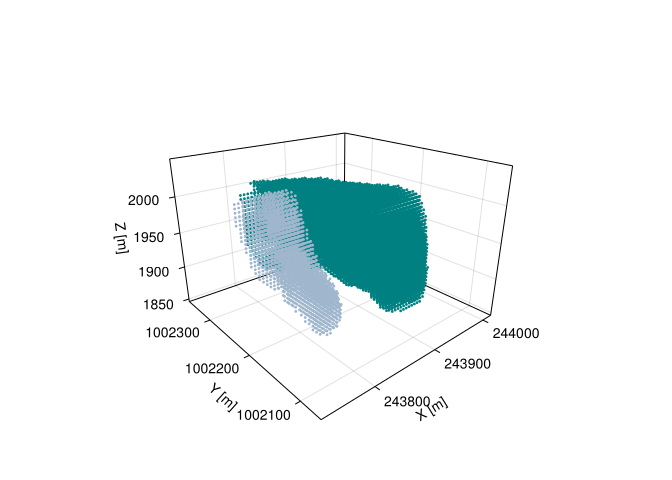

```julia
viz(groups[1].geometry, color = "teal")
viz!(groups[2].geometry, color = "slategray3")
Mke.current_figure()
```

## 8.4 Applying expressions

The mass of gold in a mining block is a function of the gold grade (`Au`), the rock density (`ρ`), and the `volume` of the block:

$$m = Au \times \rho \times V$$

Let’s use an auxiliary function to convert the `Point`s in the `geometry` column into `Box`es of sides 5x5x5. The function takes a centroid point as input and produces a box centered at the point with corners that are 2.5x2.5x2.5 units away in both directions:

```julia
box(point) = Box(point - Vec(2.5, 2.5, 2.5), point + Vec(2.5, 2.5, 2.5))
```

```
box (generic function with 1 method)
```

```julia
box.(gtb.geometry)
```

```
19548-element Vector{Box{𝔼{3}, Cartesian3D{NoDatum, Quantity{Float64, 𝐋, Unitful.FreeUnits{(m,), 𝐋, nothing}}}}}:
 Box(min: (x: 2.43938e5 m, y: 1.00223e6 m, z: 1852.5 m), max: (x: 2.43942e5 m, y: 1.00223e6 m, z: 1857.5 m))
 Box(min: (x: 2.43942e5 m, y: 1.00223e6 m, z: 1852.5 m), max: (x: 2.43948e5 m, y: 1.00223e6 m, z: 1857.5 m))
 Box(min: (x: 2.43948e5 m, y: 1.00226e6 m, z: 1852.5 m), max: (x: 2.43952e5 m, y: 1.00226e6 m, z: 1857.5 m))
 Box(min: (x: 2.43962e5 m, y: 1.00226e6 m, z: 1852.5 m), max: (x: 2.43968e5 m, y: 1.00226e6 m, z: 1857.5 m))
 Box(min: (x: 2.43968e5 m, y: 1.00226e6 m, z: 1852.5 m), max: (x: 2.43972e5 m, y: 1.00226e6 m, z: 1857.5 m))
 Box(min: (x: 2.43958e5 m, y: 1.00227e6 m, z: 1852.5 m), max: (x: 2.43962e5 m, y: 1.00227e6 m, z: 1857.5 m))
 Box(min: (x: 2.43962e5 m, y: 1.00227e6 m, z: 1852.5 m), max: (x: 2.43968e5 m, y: 1.00227e6 m, z: 1857.5 m))
 Box(min: (x: 2.43968e5 m, y: 1.00227e6 m, z: 1852.5 m), max: (x: 2.43972e5 m, y: 1.00227e6 m, z: 1857.5 m))
 Box(min: (x: 2.43928e5 m, y: 1.00222e6 m, z: 1857.5 m), max: (x: 2.43932e5 m, y: 1.00222e6 m, z: 1862.5 m))
 Box(min: (x: 2.43932e5 m, y: 1.00222e6 m, z: 1857.5 m), max: (x: 2.43938e5 m, y: 1.00222e6 m, z: 1862.5 m))
 ⋮
 Box(min: (x: 2.43752e5 m, y: 1.00221e6 m, z: 2027.5 m), max: (x: 2.43758e5 m, y: 1.00221e6 m, z: 2032.5 m))
 Box(min: (x: 2.43758e5 m, y: 1.00221e6 m, z: 2027.5 m), max: (x: 2.43762e5 m, y: 1.00221e6 m, z: 2032.5 m))
 Box(min: (x: 2.43762e5 m, y: 1.00221e6 m, z: 2027.5 m), max: (x: 2.43768e5 m, y: 1.00221e6 m, z: 2032.5 m))
 Box(min: (x: 2.43768e5 m, y: 1.00221e6 m, z: 2027.5 m), max: (x: 2.43772e5 m, y: 1.00221e6 m, z: 2032.5 m))
 Box(min: (x: 2.43772e5 m, y: 1.00221e6 m, z: 2027.5 m), max: (x: 2.43778e5 m, y: 1.00221e6 m, z: 2032.5 m))
 Box(min: (x: 2.43778e5 m, y: 1.00221e6 m, z: 2027.5 m), max: (x: 2.43782e5 m, y: 1.00221e6 m, z: 2032.5 m))
 Box(min: (x: 2.43782e5 m, y: 1.00221e6 m, z: 2027.5 m), max: (x: 2.43788e5 m, y: 1.00221e6 m, z: 2032.5 m))
 Box(min: (x: 2.43788e5 m, y: 1.00221e6 m, z: 2027.5 m), max: (x: 2.43792e5 m, y: 1.00221e6 m, z: 2032.5 m))
 Box(min: (x: 2.43792e5 m, y: 1.00221e6 m, z: 2027.5 m), max: (x: 2.43798e5 m, y: 1.00221e6 m, z: 2032.5 m))
```

The `@transform` macro modifies or creates new columns in the geotable based on expressions with existing column names. In this case, we want to replace the `geometry` column by calling the auxiliary function above:

```julia
gtb = @transform(gtb, :geometry = box(:geometry))
```

19538 rows omitted

| 19548×8 GeoTable over 19548 GeometrySet Au Continuous [ppm] | 19548×8 GeoTable over 19548 GeometrySet Ag Continuous [ppm] | 19548×8 GeoTable over 19548 GeometrySet Cu Continuous [ppm] | 19548×8 GeoTable over 19548 GeometrySet As Continuous [ppm] | 19548×8 GeoTable over 19548 GeometrySet geo Categorical [NoUnits] | 19548×8 GeoTable over 19548 GeometrySet litho Categorical [NoUnits] | 19548×8 GeoTable over 19548 GeometrySet ρ Continuous [Mg m^-3] | 19548×8 GeoTable over 19548 GeometrySet geometry Box 🖈 Cartesian{NoDatum} |
| --- | --- | --- | --- | --- | --- | --- | --- |
| 0.407 ppm | 2.335 ppm | 1311.0 ppm | 27.0 ppm | C1 | TR1 | 2.42 Mg m^-3 | Box(min: (x: 2.43938e5 m, y: 1.00223e6 m, z: 1852.5 m), max: (x: 2.43942e5 m, y: 1.00223e6 m, z: 1857.5 m)) |
| 0.407 ppm | 2.335 ppm | 1311.0 ppm | 27.0 ppm | C1 | TR1 | 1.98 Mg m^-3 | Box(min: (x: 2.43942e5 m, y: 1.00223e6 m, z: 1852.5 m), max: (x: 2.43948e5 m, y: 1.00223e6 m, z: 1857.5 m)) |
| 0.407 ppm | 2.335 ppm | 1311.0 ppm | 27.0 ppm | C1 | TR1 | 2.068 Mg m^-3 | Box(min: (x: 2.43948e5 m, y: 1.00226e6 m, z: 1852.5 m), max: (x: 2.43952e5 m, y: 1.00226e6 m, z: 1857.5 m)) |
| 0.385 ppm | 2.1 ppm | 572.0 ppm | 0.0 ppm | C1 | TR1 | 2.222 Mg m^-3 | Box(min: (x: 2.43962e5 m, y: 1.00226e6 m, z: 1852.5 m), max: (x: 2.43968e5 m, y: 1.00226e6 m, z: 1857.5 m)) |
| 0.385 ppm | 2.1 ppm | 572.0 ppm | 0.0 ppm | C1 | TR1 | 2.156 Mg m^-3 | Box(min: (x: 2.43968e5 m, y: 1.00226e6 m, z: 1852.5 m), max: (x: 2.43972e5 m, y: 1.00226e6 m, z: 1857.5 m)) |
| 0.385 ppm | 2.1 ppm | 572.0 ppm | 0.0 ppm | C1 | OX1 | 2.08 Mg m^-3 | Box(min: (x: 2.43958e5 m, y: 1.00227e6 m, z: 1852.5 m), max: (x: 2.43962e5 m, y: 1.00227e6 m, z: 1857.5 m)) |
| 0.385 ppm | 2.1 ppm | 572.0 ppm | 0.0 ppm | C1 | OX1 | 2.06 Mg m^-3 | Box(min: (x: 2.43962e5 m, y: 1.00227e6 m, z: 1852.5 m), max: (x: 2.43968e5 m, y: 1.00227e6 m, z: 1857.5 m)) |
| 0.385 ppm | 2.1 ppm | 572.0 ppm | 0.0 ppm | C1 | OX1 | 1.9 Mg m^-3 | Box(min: (x: 2.43968e5 m, y: 1.00227e6 m, z: 1852.5 m), max: (x: 2.43972e5 m, y: 1.00227e6 m, z: 1857.5 m)) |
| 0.42152 ppm | 1.422 ppm | 852.36 ppm | 22.85 ppm | C1 | TR1 | 2.024 Mg m^-3 | Box(min: (x: 2.43928e5 m, y: 1.00222e6 m, z: 1857.5 m), max: (x: 2.43932e5 m, y: 1.00222e6 m, z: 1862.5 m)) |
| 0.41747 ppm | 1.429 ppm | 832.36 ppm | 21.87 ppm | C1 | TR1 | 2.112 Mg m^-3 | Box(min: (x: 2.43932e5 m, y: 1.00222e6 m, z: 1857.5 m), max: (x: 2.43938e5 m, y: 1.00222e6 m, z: 1862.5 m)) |
| ⋮ | ⋮ | ⋮ | ⋮ | ⋮ | ⋮ | ⋮ | ⋮ |

The macro will broadcast the expression to all rows of the geotable.

**Note**

We used the `:geometry` symbol to refer to the `geometry` column instead of the usual `"geometry"` string. The `@transform` macro understands that strings can also appear as valid values in the right-hand-side of the expression, which are not columns in the geotable. To mark a string as a column name, we need to use curly braces:

```julia
@transform(gtb, {"geometry"} = box({"geometry"}))
```

**NoteTip for all users**

The use of symbols to represent column names is preferred in macros.

The mass of gold on each mining block can be computed now that the geometries have `volume`:

```julia
@transform(gtb, :m = :Au * :ρ * volume(:geometry))
```

19538 rows omitted

| 19548×9 GeoTable over 19548 GeometrySet Au Continuous [ppm] | 19548×9 GeoTable over 19548 GeometrySet Ag Continuous [ppm] | 19548×9 GeoTable over 19548 GeometrySet Cu Continuous [ppm] | 19548×9 GeoTable over 19548 GeometrySet As Continuous [ppm] | 19548×9 GeoTable over 19548 GeometrySet geo Categorical [NoUnits] | 19548×9 GeoTable over 19548 GeometrySet litho Categorical [NoUnits] | 19548×9 GeoTable over 19548 GeometrySet ρ Continuous [Mg m^-3] | 19548×9 GeoTable over 19548 GeometrySet m Continuous [Mg ppm] | 19548×9 GeoTable over 19548 GeometrySet geometry Box 🖈 Cartesian{NoDatum} |
| --- | --- | --- | --- | --- | --- | --- | --- | --- |
| 0.407 ppm | 2.335 ppm | 1311.0 ppm | 27.0 ppm | C1 | TR1 | 2.42 Mg m^-3 | 123.117 Mg ppm | Box(min: (x: 2.43938e5 m, y: 1.00223e6 m, z: 1852.5 m), max: (x: 2.43942e5 m, y: 1.00223e6 m, z: 1857.5 m)) |
| 0.407 ppm | 2.335 ppm | 1311.0 ppm | 27.0 ppm | C1 | TR1 | 1.98 Mg m^-3 | 100.732 Mg ppm | Box(min: (x: 2.43942e5 m, y: 1.00223e6 m, z: 1852.5 m), max: (x: 2.43948e5 m, y: 1.00223e6 m, z: 1857.5 m)) |
| 0.407 ppm | 2.335 ppm | 1311.0 ppm | 27.0 ppm | C1 | TR1 | 2.068 Mg m^-3 | 105.209 Mg ppm | Box(min: (x: 2.43948e5 m, y: 1.00226e6 m, z: 1852.5 m), max: (x: 2.43952e5 m, y: 1.00226e6 m, z: 1857.5 m)) |
| 0.385 ppm | 2.1 ppm | 572.0 ppm | 0.0 ppm | C1 | TR1 | 2.222 Mg m^-3 | 106.934 Mg ppm | Box(min: (x: 2.43962e5 m, y: 1.00226e6 m, z: 1852.5 m), max: (x: 2.43968e5 m, y: 1.00226e6 m, z: 1857.5 m)) |
| 0.385 ppm | 2.1 ppm | 572.0 ppm | 0.0 ppm | C1 | TR1 | 2.156 Mg m^-3 | 103.758 Mg ppm | Box(min: (x: 2.43968e5 m, y: 1.00226e6 m, z: 1852.5 m), max: (x: 2.43972e5 m, y: 1.00226e6 m, z: 1857.5 m)) |
| 0.385 ppm | 2.1 ppm | 572.0 ppm | 0.0 ppm | C1 | OX1 | 2.08 Mg m^-3 | 100.1 Mg ppm | Box(min: (x: 2.43958e5 m, y: 1.00227e6 m, z: 1852.5 m), max: (x: 2.43962e5 m, y: 1.00227e6 m, z: 1857.5 m)) |
| 0.385 ppm | 2.1 ppm | 572.0 ppm | 0.0 ppm | C1 | OX1 | 2.06 Mg m^-3 | 99.1375 Mg ppm | Box(min: (x: 2.43962e5 m, y: 1.00227e6 m, z: 1852.5 m), max: (x: 2.43968e5 m, y: 1.00227e6 m, z: 1857.5 m)) |
| 0.385 ppm | 2.1 ppm | 572.0 ppm | 0.0 ppm | C1 | OX1 | 1.9 Mg m^-3 | 91.4375 Mg ppm | Box(min: (x: 2.43968e5 m, y: 1.00227e6 m, z: 1852.5 m), max: (x: 2.43972e5 m, y: 1.00227e6 m, z: 1857.5 m)) |
| 0.42152 ppm | 1.422 ppm | 852.36 ppm | 22.85 ppm | C1 | TR1 | 2.024 Mg m^-3 | 106.645 Mg ppm | Box(min: (x: 2.43928e5 m, y: 1.00222e6 m, z: 1857.5 m), max: (x: 2.43932e5 m, y: 1.00222e6 m, z: 1862.5 m)) |
| 0.41747 ppm | 1.429 ppm | 832.36 ppm | 21.87 ppm | C1 | TR1 | 2.112 Mg m^-3 | 110.212 Mg ppm | Box(min: (x: 2.43932e5 m, y: 1.00222e6 m, z: 1857.5 m), max: (x: 2.43938e5 m, y: 1.00222e6 m, z: 1862.5 m)) |
| ⋮ | ⋮ | ⋮ | ⋮ | ⋮ | ⋮ | ⋮ | ⋮ | ⋮ |

**Note**

The `@transform` macro can be used with both geotables and geospatial partitions.

## 8.5 Combining results

We can use the `@combine` macro to reduce columns of geotables in a geospatial partition obtained with the `@groupby` macro. The macro is similar to the `@transform` macro, but expects valid reduction functions such as `sum`, `mean`, `std`. Reduction functions take a vector of values as input and produce a single scalar as output:

```julia
groups = @groupby(gtb, :geo)

@combine(groups, :μ = mean(:Au), :σ = std(:Au))
```

| 2×4 GeoTable over 2 GeometrySet geo Categorical [NoUnits] | 2×4 GeoTable over 2 GeometrySet μ Continuous [ppm] | 2×4 GeoTable over 2 GeometrySet σ Continuous [ppm] | 2×4 GeoTable over 2 GeometrySet geometry Multi 🖈 Cartesian{NoDatum} |
| --- | --- | --- | --- |
| C1 | 0.581937 ppm | 0.136264 ppm | Multi(17153×Box) |
| C2 | 0.484622 ppm | 0.095799 ppm | Multi(2395×Box) |

Note that the macro reduces the geometry column and produces a new complex `Multi` geometry with all the `Box`es that are inside each geological unit. This is a very advanced feature of the framework that **cannot be represented with the simple features standard**. It is also possible to use a custom reduction function for the `geometry` column:

```julia
groups = @groupby(gtb, :geo)

@combine(groups, :μ = mean(:Au), :σ = std(:Au), :geometry = first(:geometry))
```

| 2×4 GeoTable over 2 GeometrySet geo Categorical [NoUnits] | 2×4 GeoTable over 2 GeometrySet μ Continuous [ppm] | 2×4 GeoTable over 2 GeometrySet σ Continuous [ppm] | 2×4 GeoTable over 2 GeometrySet geometry Box 🖈 Cartesian{NoDatum} |
| --- | --- | --- | --- |
| C1 | 0.581937 ppm | 0.136264 ppm | Box(min: (x: 2.43938e5 m, y: 1.00223e6 m, z: 1852.5 m), max: (x: 2.43942e5 m, y: 1.00223e6 m, z: 1857.5 m)) |
| C2 | 0.484622 ppm | 0.095799 ppm | Box(min: (x: 2.43792e5 m, y: 1.00214e6 m, z: 1872.5 m), max: (x: 2.43798e5 m, y: 1.00214e6 m, z: 1877.5 m)) |

## 8.6 Answering questions

Let’s recall our original business question:

*What is the total mass of gold that will be mined from each geological unit?*

We can now answer this question with three lines of code:

```julia
groups = @groupby(gtb, :geo)

mass = @transform(groups, :m = :Au * :ρ * volume(:geometry))

answer = @combine(mass, :m = sum(:m))
```

| 2×3 GeoTable over 2 GeometrySet geo Categorical [NoUnits] | 2×3 GeoTable over 2 GeometrySet m Continuous [Mg ppm] | 2×3 GeoTable over 2 GeometrySet geometry Multi 🖈 Cartesian{NoDatum} |
| --- | --- | --- |
| C1 | 2.53302e6 Mg ppm | Multi(17153×Box) |
| C2 | 3.29241e5 Mg ppm | Multi(2395×Box) |

**NoteTip for all users**

We can simplify the code further using the `@chain` macro. It forwards the resulting geotable or geospatial partition to the next macro:

```julia
@chain gtb begin
  @groupby(:geo)
  @transform(:m = :Au * :ρ * volume(:geometry))
  @combine(:m = sum(:m))
end
```

| 2×3 GeoTable over 2 GeometrySet geo Categorical [NoUnits] | 2×3 GeoTable over 2 GeometrySet m Continuous [Mg ppm] | 2×3 GeoTable over 2 GeometrySet geometry Multi 🖈 Cartesian{NoDatum} |
| --- | --- | --- |
| C1 | 2.53302e6 Mg ppm | Multi(17153×Box) |
| C2 | 3.29241e5 Mg ppm | Multi(2395×Box) |

Wickham, Hadley. 2011. “The Split-Apply-Combine Strategy for Data Analysis.” *Journal of Statistical Software* 40 (1): 1–29. https://doi.org/10.18637/jss.v040.i01.